# 범주 R실습 2주차

```r
# 필요한 패키지 불러오기
library(tidyverse)
library(plyr)
library(magrittr)
library(data.table)
```

## **일반화 선형모형(Generalized Linear Model)**

일반화 선형모형은 `glm()` 함수를 사용한다. `glm()`함수의 사용은 `lm()`함수와 유사하지만 추가로 family라는 인자를 지정해주는데, 종속변수가 따르는 분포를 지정해주면 된다.

- glm(formula, family = family(link=function), data)

## **로지스틱 회귀 모형 (Logistic Regression Model)**

로지스틱 회귀는 종속변수가 이항분포를 따르므로 family = binomial로 지정해주면 된다. mtcars 데이터의 vs(엔진 종류) 변수를 예측하는 모형을 만들어보자.

```r
# mtcars 데이터 불러오기
data(mtcars)
mtcars %>% str()
```

```
## 'data.frame':    32 obs. of  11 variables:
##  $ mpg : num  21 21 22.8 21.4 18.7 18.1 14.3 24.4 22.8 19.2 ...
##  $ cyl : num  6 6 4 6 8 6 8 4 4 6 ...
##  $ disp: num  160 160 108 258 360 ...
##  $ hp  : num  110 110 93 110 175 105 245 62 95 123 ...
##  $ drat: num  3.9 3.9 3.85 3.08 3.15 2.76 3.21 3.69 3.92 3.92 ...
##  $ wt  : num  2.62 2.88 2.32 3.21 3.44 ...
##  $ qsec: num  16.5 17 18.6 19.4 17 ...
##  $ vs  : num  0 0 1 1 0 1 0 1 1 1 ...
##  $ am  : num  1 1 1 0 0 0 0 0 0 0 ...
##  $ gear: num  4 4 4 3 3 3 3 4 4 4 ...
##  $ carb: num  4 4 1 1 2 1 4 2 2 4 ...
```

```r
#로지스틱 모델 적합
logit_model1 <- glm(vs ~ mpg, family = binomial, data = mtcars)
summary(logit_model1)
```

```
##
## Call:
## glm(formula = vs ~ mpg, family = binomial, data = mtcars)
##
## Deviance Residuals:
##     Min       1Q   Median       3Q      Max
## -2.2127  -0.5121  -0.2276   0.6402   1.6980
##
## Coefficients:
##             Estimate Std. Error z value Pr(>|z|)
## (Intercept)  -8.8331     3.1623  -2.793  0.00522 **
## mpg           0.4304     0.1584   2.717  0.00659 **
## ---
## Signif. codes:  0 '***' 0.001 '**' 0.01 '*' 0.05 '.' 0.1 ' ' 1
##
## (Dispersion parameter for binomial family taken to be 1)
##
##     Null deviance: 43.860  on 31  degrees of freedom
## Residual deviance: 25.533  on 30  degrees of freedom
## AIC: 29.533
##
## Number of Fisher Scoring iterations: 6
```

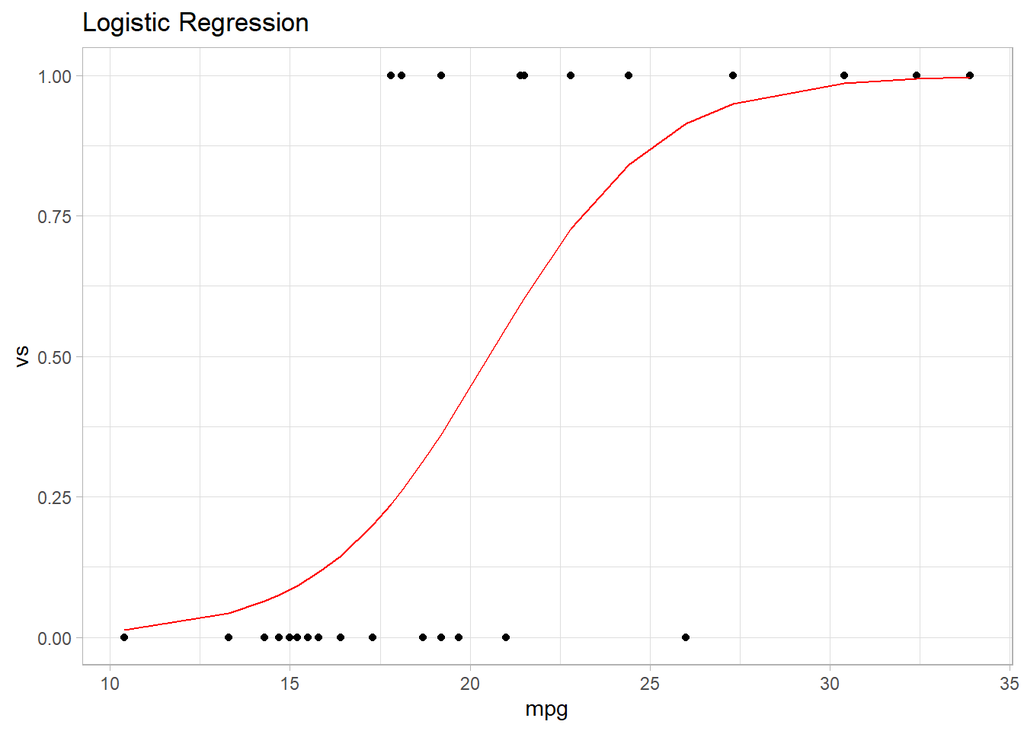

```r
mtcars %>%
  ggplot() +
  geom_point(aes(x=mpg, y=vs)) +
  geom_line(aes(x=mpg, y =fitted(logit_model1)), color = "red") +
  labs(title = 'Logistic Regression') +
  theme_light()
```

```r
# 변수 선택법 적용
logit_model3 <- glm(vs ~ mpg +am + wt, family=binomial, data= mtcars)
logit_model2 <- step(logit_model3)
```

```
## Start:  AIC=27.34
## vs ~ mpg + am + wt
##
##        Df Deviance    AIC
## - wt    1   20.646 26.646
## <none>      19.342 27.342
## - mpg   1   21.532 27.532
## - am    1   25.298 31.298
##
## Step:  AIC=26.65
## vs ~ mpg + am
##
##        Df Deviance    AIC
## <none>      20.646 26.646
## - am    1   25.533 29.533
## - mpg   1   42.953 46.953
```

```r
summary(logit_model2)
```

```
##
## Call:
## glm(formula = vs ~ mpg + am, family = binomial, data = mtcars)
##
## Deviance Residuals:
##      Min        1Q    Median        3Q       Max
## -2.05888  -0.44544  -0.08765   0.33335   1.68405
##
## Coefficients:
##             Estimate Std. Error z value Pr(>|z|)
## (Intercept) -12.7051     4.6252  -2.747  0.00602 **
## mpg           0.6809     0.2524   2.698  0.00697 **
## am           -3.0073     1.5995  -1.880  0.06009 .
## ---
## Signif. codes:  0 '***' 0.001 '**' 0.01 '*' 0.05 '.' 0.1 ' ' 1
##
## (Dispersion parameter for binomial family taken to be 1)
##
##     Null deviance: 43.860  on 31  degrees of freedom
## Residual deviance: 20.646  on 29  degrees of freedom
## AIC: 26.646
##
## Number of Fisher Scoring iterations: 6
```

### **유의성 검정**

```r
library(lmtest) # LRT(가능도비 검정) 패키지
lrtest(logit_model2, logit_model3)
```

```
## Likelihood ratio test
##
## Model 1: vs ~ mpg + am
## Model 2: vs ~ mpg + am + wt
##   #Df   LogLik Df Chisq Pr(>Chisq)
## 1   3 -10.3231
## 2   4  -9.6711  1 1.304     0.2535
```

```r
# 이탈도 - anova(test = "Chisq") 통해서 확인 가능
anova(logit_model3, test = "Chisq")
```

```
## Analysis of Deviance Table
##
## Model: binomial, link: logit
##
## Response: vs
##
## Terms added sequentially (first to last)
##
##
##      Df Deviance Resid. Df Resid. Dev  Pr(>Chi)
## NULL                    31     43.860
## mpg   1   18.327        30     25.533 1.861e-05 ***
## am    1    4.887        29     20.646   0.02706 *
## wt    1    1.304        28     19.342   0.25348
## ---
## Signif. codes:  0 '***' 0.001 '**' 0.01 '*' 0.05 '.' 0.1 ' ' 1
```

각 변수를 mpg -> am -> wt 순서로 추가할 때의 모형의 이탈도를 Deviance Resid. 에서 확인할 수 있다. mpg만 설명변수로 갖는 모형의 이탈도는 18.327, mpg와 am을 설명변수로 갖는 모형의 이탈도는 18.327 + 4.887 = 23.214와 같다. 모형 이탈도는 위의 모형 summary 의 `Null Deviance` 에서 `Residual Deviance`를 뺀 값과 같다.

### **예측**

```r
# 예측
predict(logit_model2, type = "response") # 사후확률 예측값
```

```
##           Mazda RX4       Mazda RX4 Wag          Datsun 710      Hornet 4 Drive
##         0.195752093         0.195752093         0.453286237         0.866062468
##   Hornet Sportabout             Valiant          Duster 360           Merc 240D
##         0.507024063         0.406017350         0.048894865         0.980340613
##            Merc 230            Merc 280           Merc 280C          Merc 450SE
##         0.943740285         0.591110583         0.357844862         0.176823422
##          Merc 450SL         Merc 450SLC  Cadillac Fleetwood Lincoln Continental
##         0.283901447         0.086659370         0.003598826         0.003598826
##   Chrysler Imperial            Fiat 128         Honda Civic      Toyota Corolla
##         0.063234437         0.998255316         0.993224169         0.999371042
##       Toyota Corona    Dodge Challenger         AMC Javelin          Camaro Z28
##         0.873766034         0.104252045         0.086659370         0.025360551
##    Pontiac Firebird           Fiat X1-9       Porsche 914-2        Lotus Europa
##         0.591110583         0.946684602         0.879906401         0.993224169
##      Ford Pantera L        Ferrari Dino       Maserati Bora          Volvo 142E
##         0.007006782         0.091267566         0.004075891         0.242193639
```

```r
result <- data.frame(actual_vs = mtcars$vs,
                     pred_prob = predict(logit_model2, type = "response")) %>%
  mutate(pred_vs = ifelse(pred_prob > 0.5, 1, 0)) # cut-off point : 0.5로 설정

result %>% head()
```

```
##                   actual_vs pred_prob pred_vs
## Mazda RX4                 0 0.1957521       0
## Mazda RX4 Wag             0 0.1957521       0
## Datsun 710                1 0.4532862       0
## Hornet 4 Drive            1 0.8660625       1
## Hornet Sportabout         0 0.5070241       1
## Valiant                   1 0.4060174       0
```